# 6.3 Market Basket Analysis

## A case study

The dataset we are using today comes from [UCI Machine Learning repository](http://archive.ics.uci.edu/ml/datasets/online+retail). The dataset is called “Online Retail” and can be found [here](http://archive.ics.uci.edu/ml/datasets/online+retail). It contains all the transactions occurring between 01/12/2010 and 09/12/2011 for a UK-based and registered online retail.

## Load the packages

```r
library(tidyverse)
library(readxl)
library(knitr)
library(ggplot2)
library(lubridate)
library(arules)
library(arulesViz)
library(plyr)
```

## Data preprocessing and exploring

```r
retail <- read_excel('Datasets/Online retail.xlsx')
retail <- retail[complete.cases(retail), ]
dim(retail)
```

```
 [1] 406829      8
```

```r
retail
```

```
 # A tibble: 406,829 x 8
    InvoiceNo StockCode Description Quantity InvoiceDate         UnitPrice
    <chr>     <chr>     <chr>          <dbl> <dttm>                  <dbl>
  1 536365    85123A    WHITE HANG~        6 2010-12-01 08:26:00      2.55
  2 536365    71053     WHITE META~        6 2010-12-01 08:26:00      3.39
  3 536365    84406B    CREAM CUPI~        8 2010-12-01 08:26:00      2.75
  4 536365    84029G    KNITTED UN~        6 2010-12-01 08:26:00      3.39
  5 536365    84029E    RED WOOLLY~        6 2010-12-01 08:26:00      3.39
  6 536365    22752     SET 7 BABU~        2 2010-12-01 08:26:00      7.65
  7 536365    21730     GLASS STAR~        6 2010-12-01 08:26:00      4.25
  8 536366    22633     HAND WARME~        6 2010-12-01 08:28:00      1.85
  9 536366    22632     HAND WARME~        6 2010-12-01 08:28:00      1.85
 10 536367    84879     ASSORTED C~       32 2010-12-01 08:34:00      1.69
 # ... with 406,819 more rows, and 2 more variables: CustomerID <dbl>,
 #   Country <chr>
```

```r
retail <- retail %>% mutate(Description = as.factor(Description))
retail <- retail %>% mutate(Country = as.factor(Country))
retail$Date <- as.Date(retail$InvoiceDate)
retail$Time <- format(retail$InvoiceDate,"%H:%M:%S")
retail$InvoiceNo <- as.numeric(as.character(retail$InvoiceNo))
```

After preprocessing, the dataset includes 406,829 records and 10 fields: InvoiceNo, StockCode, Description, Quantity, InvoiceDate, UnitPrice, CustomerID, Country, Date, Time.

### What time do people often purchase online?

In order to find the answer to this question, we need to extract “hour” from the time column.

```r
retail$Time <- as.factor(retail$Time)
a <- hms(as.character(retail$Time))
retail$Time = hour(a)
plyr::count(hour(a))
```

```
     x  freq
 1   6    41
 2   7   383
 3   8  8792
 4   9 22464
 5  10 38951
 6  11 50249
 7  12 73342
 8  13 65062
 9  14 55075
 10 15 46220
 11 16 24997
 12 17 13734
 13 18  3137
 14 19  3511
 15 20   871
```

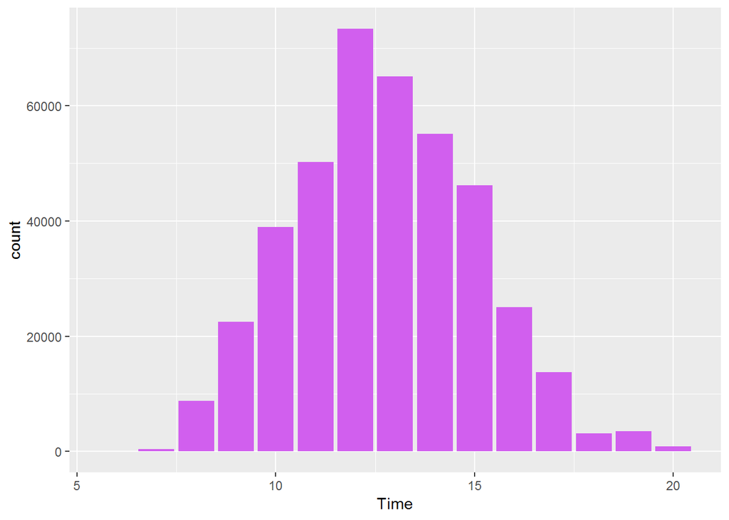

```r
retail %>%
  ggplot(aes(x=Time))+ geom_histogram(stat="count",fill="mediumorchid2")
```

There is a clear effect of hour of day on order volume. Most orders happened between 11:00-15:00.

### Top 10 best sellers

```r
detach("package:plyr", unload=TRUE)
tmp <- retail %>%
  group_by(StockCode, Description) %>%
  summarize(count = n()) %>%
  arrange(desc(count))
tmp <- head(tmp, n=10)
tmp
```

```
 # A tibble: 10 x 3
 # Groups:   StockCode [10]
    StockCode Description                        count
    <chr>     <fct>                              <int>
  1 85123A    WHITE HANGING HEART T-LIGHT HOLDER  2070
  2 22423     REGENCY CAKESTAND 3 TIER            1905
  3 85099B    JUMBO BAG RED RETROSPOT             1662
  4 84879     ASSORTED COLOUR BIRD ORNAMENT       1418
  5 47566     PARTY BUNTING                       1416
  6 20725     LUNCH BAG RED RETROSPOT             1358
  7 22720     SET OF 3 CAKE TINS PANTRY DESIGN    1232
  8 POST      POSTAGE                             1196
  9 20727     LUNCH BAG  BLACK SKULL.             1126
 10 21212     PACK OF 72 RETROSPOT CAKE CASES     1080
```

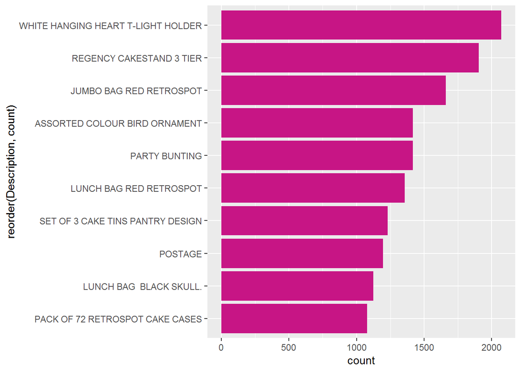

```r
tmp %>%
  ggplot(aes(x=reorder(Description,count), y=count))+
  geom_bar(stat="identity",fill="mediumvioletred")+
  coord_flip()
```